# Advanced

# apodisation and artefacts

Artefacts are inherent to FT

Apodisation consists multiplying the time domain data by a function to reduce these artefacts.

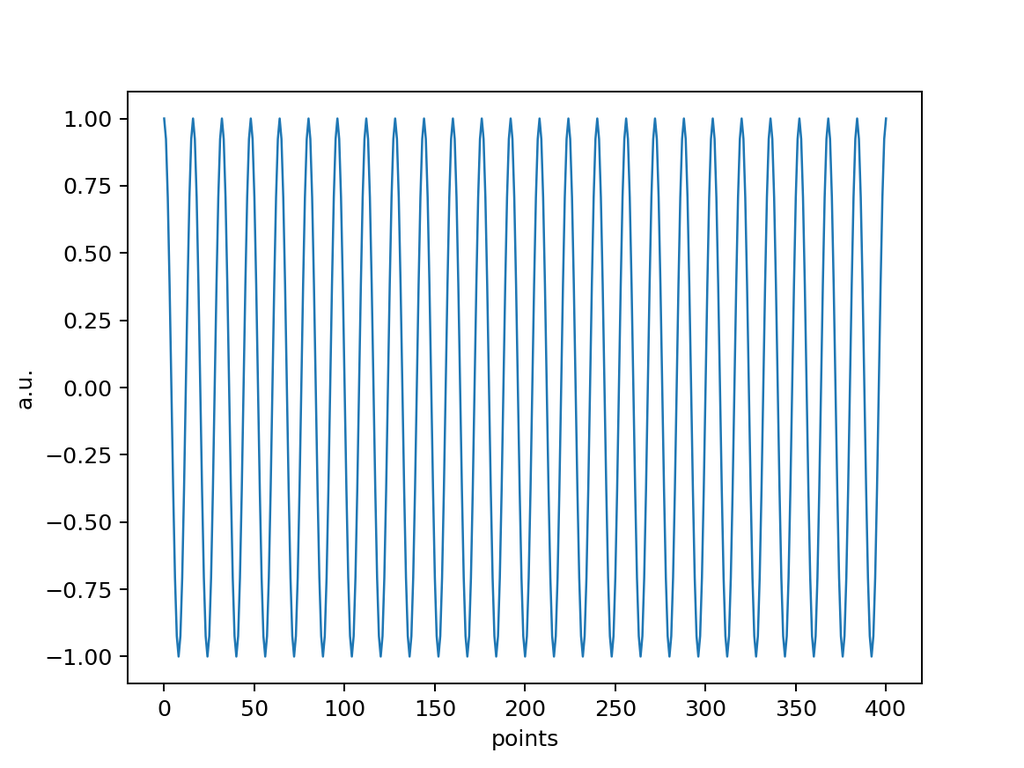

```
1D data-set
Axis F1 :FT-ICR report axis at 700.000000 kHz,  4096 real points,  from physical mz =  142.857   to m/z = 10000.000  R max (M=400) = 1462
data-set is real
```

```python
N = 4*1024; SW = 700000
t = np.arange(N)/(2*SW)
y = np.cos(2*np.pi*0.125*SW*t)
d = FTICRData(buffer=y); d.axis1.specwidth=SW; d.display(zoom=(0,400))
```

after Real Fourier Transform (`rfft()`) only half of the points are left.

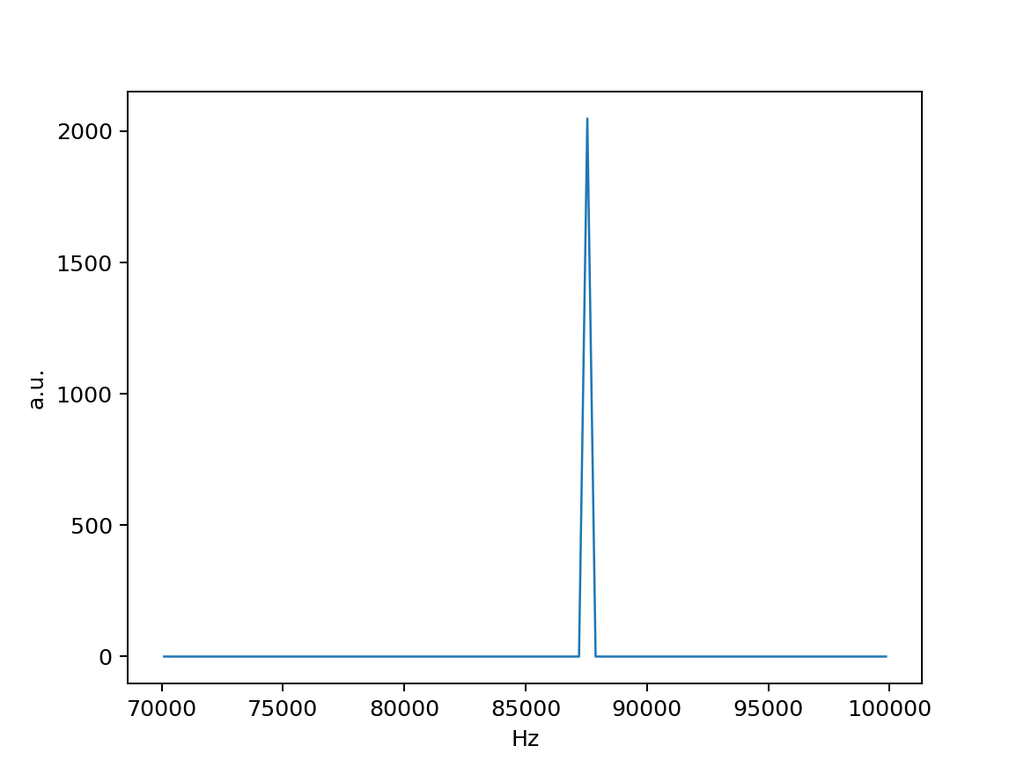

```
1D data-set
Axis F1 :FT-ICR report axis at 700.000000 kHz,  2048 real points,  from physical mz =  142.857   to m/z = 10000.000  R max (M=400) = 731
data-set is real
```

```python
d.copy().rfft().modulus().set_unit('Hz').display(zoom=(70000,100000))
```

Applying zerofilling to the data-set

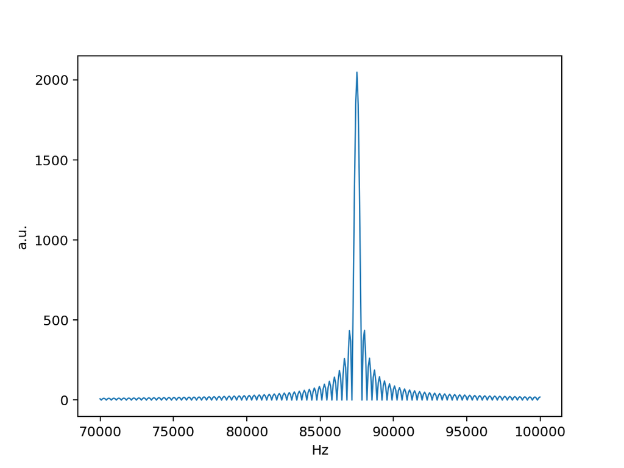

```
1D data-set
Axis F1 :FT-ICR report axis at 700.000000 kHz,  8192 real points,  from physical mz =  142.857   to m/z = 10000.000  R max (M=400) = 2925
data-set is real
```

```python
d.copy().zf(4).rfft().modulus().set_unit('Hz').display(zoom=(70000,100000))
```

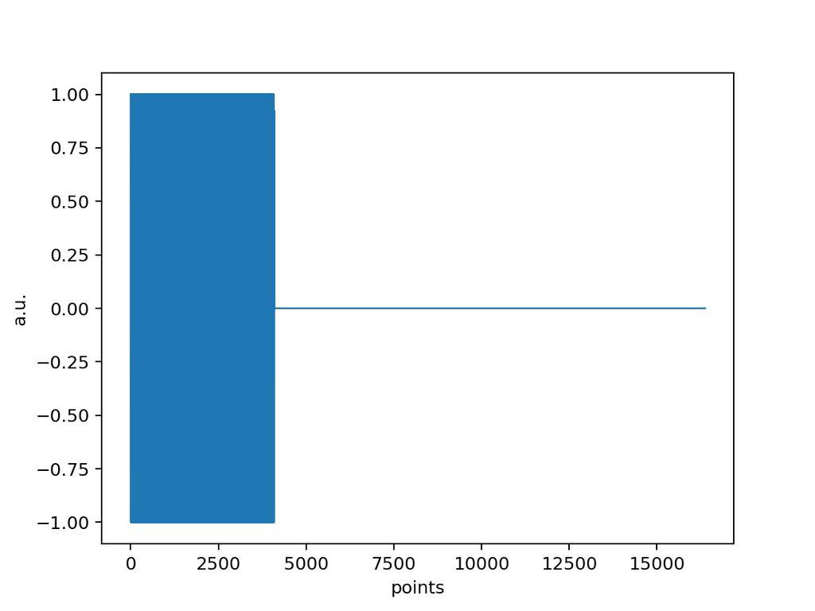

```
1D data-set
Axis F1 :FT-ICR report axis at 700.000000 kHz,  16384 real points,  from physical mz =  142.857   to m/z = 10000.000  R max (M=400) = 5851
data-set is real
```

```python
d.copy().zf(4).display()
```

```python
zm1 = (80000,95000)
zm2 = (85000,90000)
def slide_apod(zm=zm1):
    (fig, ax) = plt.subplots(nrows=4, ncols=2)
    dd = d.copy().zf(4).display(figure=ax[0,0], title='transient')
    dd.rfft().modulus().set_unit('Hz').display(zoom=zm,figure=ax[0,1], title='spectrum')
    dd = d.copy().apod_sin(0.5).zf(4).display(figure=ax[1,0], label='sine bell')
    dd.rfft().modulus().set_unit('Hz').display(zoom=zm,figure=ax[1,1])
    dd = d.copy().hamming().zf(4).display(figure=ax[2,0], label='hamming')
    dd.rfft().modulus().set_unit('Hz').display(zoom=zm,figure=ax[2,1])
    dd = d.copy().hanning().zf(4).display(figure=ax[3,0], label='hanning')
    dd.rfft().modulus().set_unit('Hz').display(zoom=zm,figure=ax[3,1])
def slide_apod2(zm=zm2):
    dd = d.copy().zf(4).rfft().modulus().set_unit('Hz')
    dd.mult(1/dd.absmax).display(zoom=zm,label='None', title='Comparing apodisations')
    for apod in ['apod_sin(0.5)','hamming()','hanning()']:
        dd = eval("d.copy().%s.zf(4).rfft().modulus().set_unit('Hz')"%apod)
        dd.mult(1/dd.absmax).display(zoom=zm, new_fig=False, label=apod)
def slide_apod2b(zm=zm2):
    dd = d.copy().apod_sin(0.5).zf(4).rfft().modulus().set_unit('Hz')
    dd.mult(1/dd.absmax).display(zoom=zm,label='apod_sin', title='Kaiser apodisations',mpldic={"linestyle":(0,(1,1))})
    for apod in ['hamming()']:
        dd = eval("d.copy().%s.zf(4).rfft().modulus().set_unit('Hz')"%apod)
        dd.mult(1/dd.absmax).display(zoom=zm, new_fig=False, label=apod, mpldic={"linestyle":(0,(1,1))})
    for apod in ['kaiser(2.6)','kaiser(4)','kaiser(5.5)']:
        dd = eval("d.copy().%s.zf(4).rfft().modulus().set_unit('Hz')"%apod)
        dd.mult(1/dd.absmax).display(zoom=zm, new_fig=False, label=apod)
def slide_apod3(zm=zm2):
    ds = d.copy().chsize(16*1024).rfft().modulus().set_unit('Hz')
    ds.mult(1/ds.absmax).display(zoom=zm, title='sliding apodisation')
    for n in [2, 2.5, 3, 3.5, 4]:
        dd = d.copy().chsize(int(n*1024)).chsize(16*1024).rfft().modulus().set_unit('Hz')
        dd.mult(1/dd.absmax).display(zoom=zm,new_fig=False)
#        ds += n*dd
def slide_apod3b(zm=zm2):
    global ds
    ds = d.copy().kaiser(2).zf(4).rfft().modulus().set_unit('Hz')
    ds.mult(1/ds.absmax).display(zoom=zm, title='sliding apodisation')
    for n in [2.5, 3, 3.5, 4, 4.5]:
        dd = d.copy().kaiser(n).zf(4).rfft().modulus().set_unit('Hz')
        dd.mult(1/dd.absmax).display(zoom=zm,new_fig=False)
        ds += n*dd
```

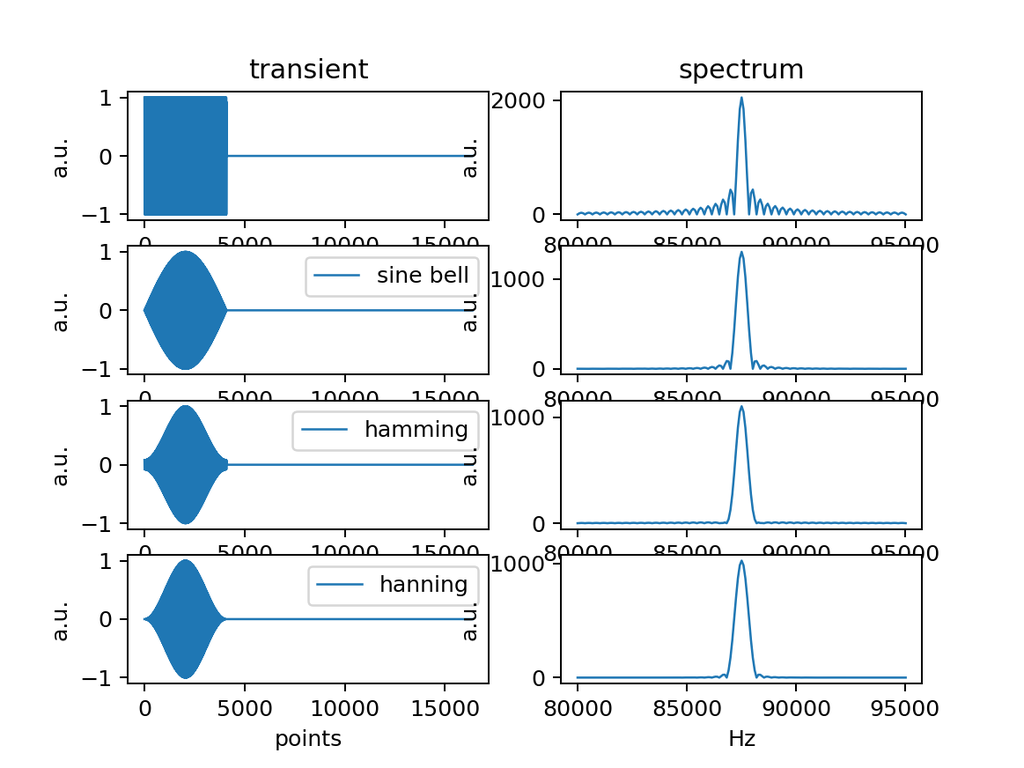

```python
slide_apod()
```

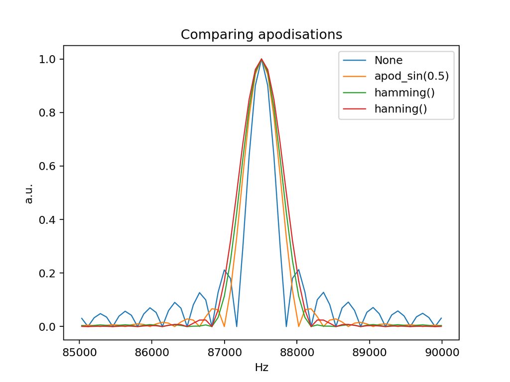

```python
slide_apod2()
```

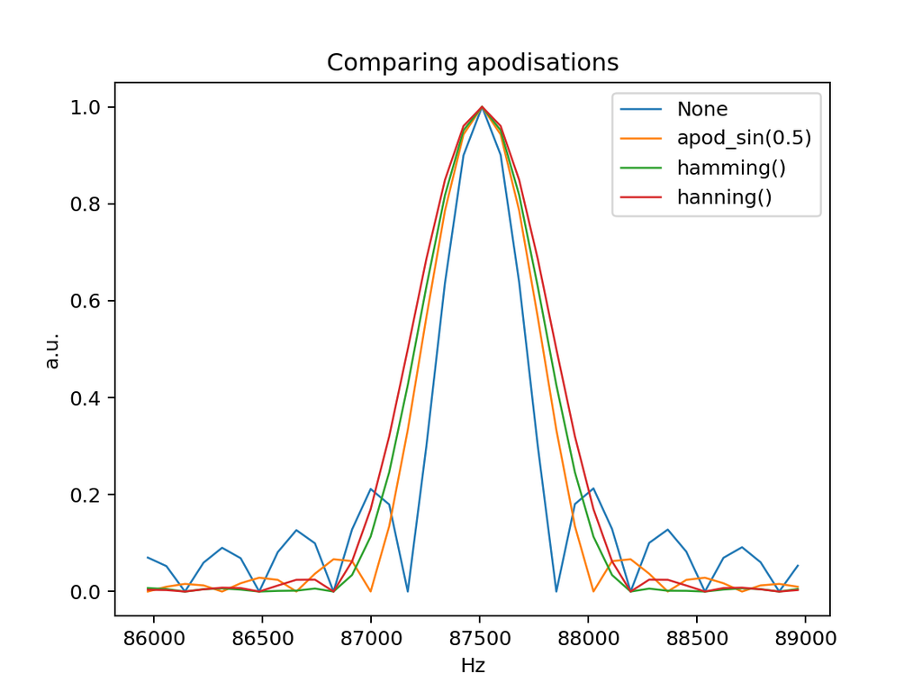

```python
slide_apod2(zm=(86000,89000))
```

It is possible to truncate the transient at varying position, to move the truncation artifacts.

On a complex spectrum, this might allow to detect artefacts from real signals

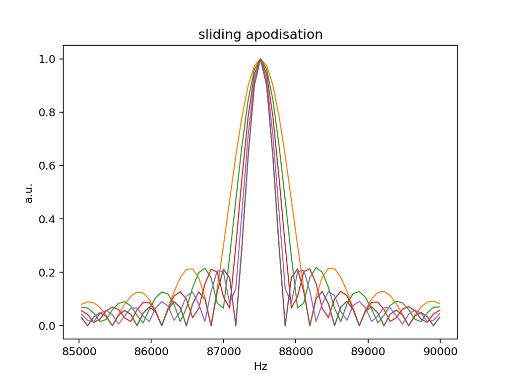

```python
slide_apod3()
```

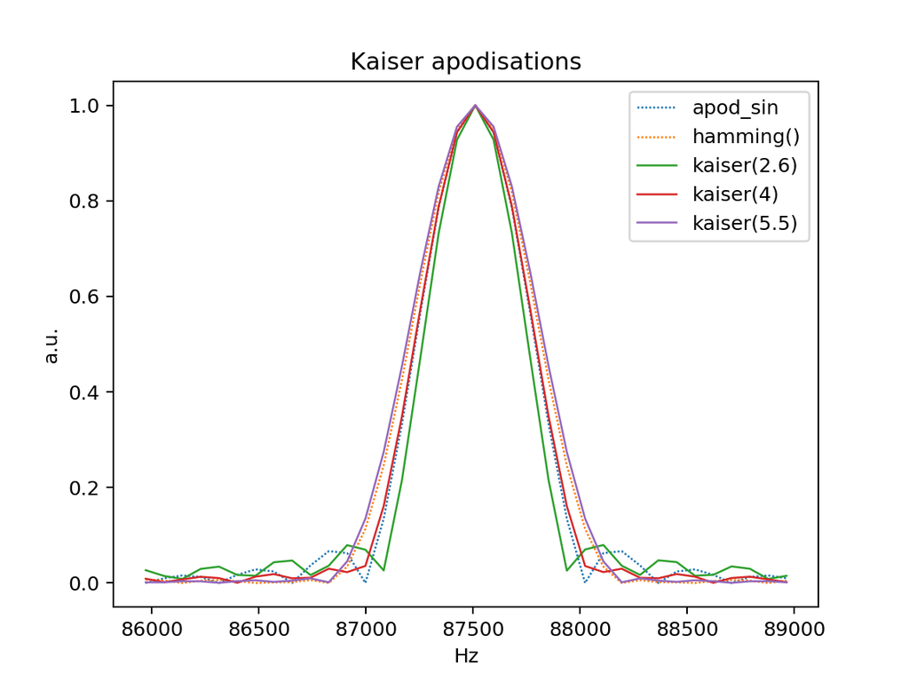

```python
slide_apod2b(zm=(86000,89000))
```

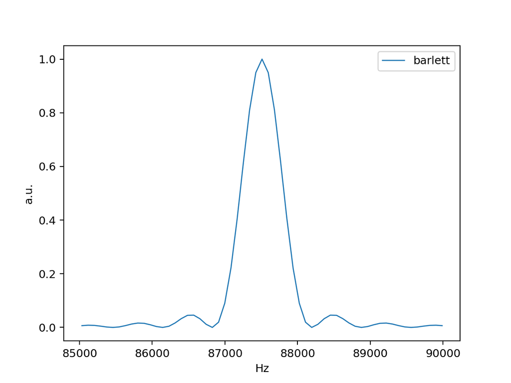

```
1D data-set
Axis F1 :FT-ICR report axis at 700.000000 kHz,  8192 real points,  from physical mz =  142.857   to m/z = 10000.000  R max (M=400) = 2925
data-set is real
```

```python
dd = d.copy()
dd.set_buffer(dd.get_buffer()*np.bartlett(dd.size1))
dd.zf(4).rfft().modulus().set_unit('Hz')
dd.mult(1/dd.absmax).display(zoom=zm2, label='barlett')
```

```python
ls files/FTICR-Files/ESI_pos_Ubiquitin_000006.d/
```

```
ESI_pos_150_3000.m/ desktop.ini*        fid*
```

## On real Data

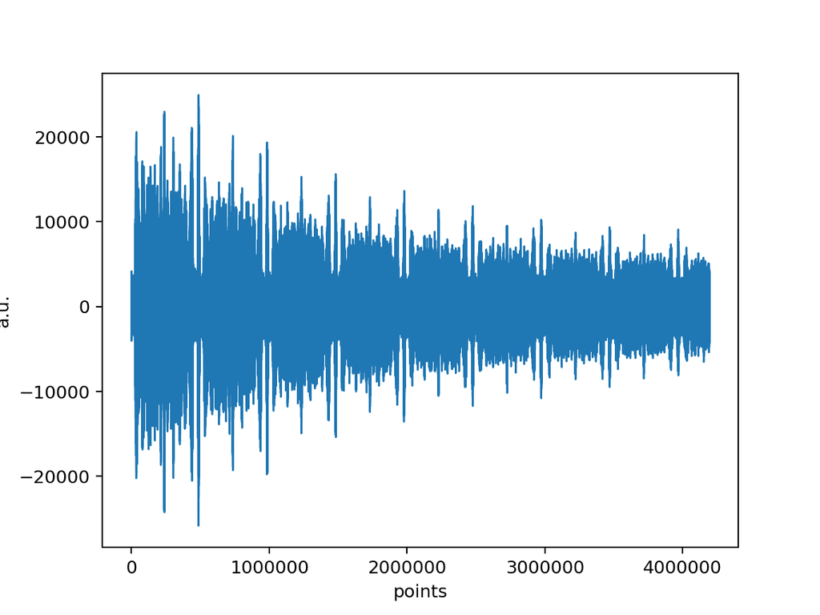

```
1D data-set
Axis F1 :FT-ICR report axis at 625.000000 kHz,  4194304 real points,  from physical mz =  294.830   to m/z = 3000.000  R max (M=400) = 3091537
data-set is real
```

```python
d = Apex.Import_1D('files/FTICR-Files/ESI_pos_Ubiquitin_000006.d')#080617-insulin_2M_MS_000001.d')
d.display(scale=1)
```

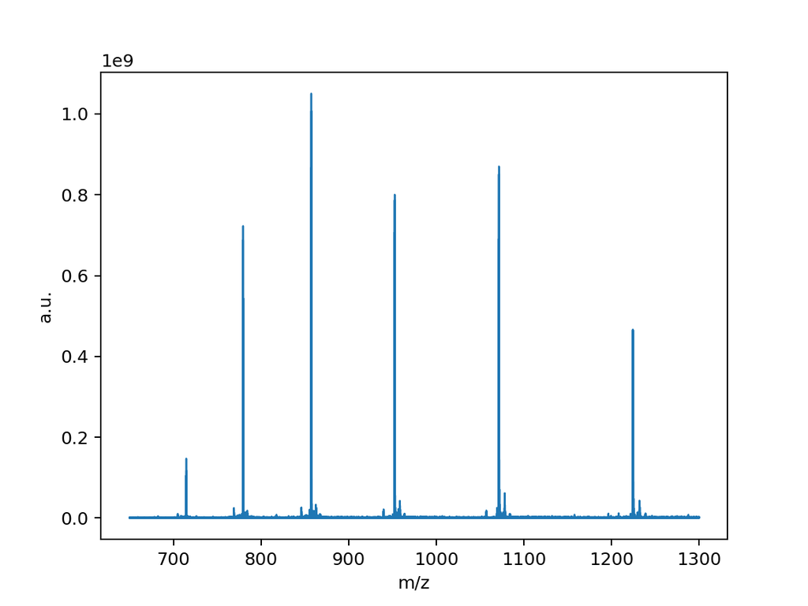

```
1D data-set
Axis F1 :FT-ICR report axis at 625.000000 kHz,  8388608 real points,  from physical mz =  294.830   to m/z = 3000.000  R max (M=400) = 6183075
data-set is real
```

```python
d.copy().hanning().zf(4).rfft().modulus().set_unit('m/z').display(zoom=(650,1300))
```

```python
def real1(trunc=None):
    d = Apex.Import_1D('files/FTICR-Files/ESI_pos_Ubiquitin_000006.d')
    zm1 = (714.2,715.5)
    zm1b = (714.7, 714.75)
    zm2 = (1223.5, 1225.5)
    zm2b= (1224.45, 1224.6)
    if trunc: d.chsize(trunc)
    (fig,ax) = plt.subplots(nrows=2, ncols=2)
    d1=d.copy().hamming().zf(4).rfft().modulus().set_unit('m/z').display(zoom=zm1, label='Ham', figure=ax[0,0])
    d2=d.copy().kaiser(2.5).zf(4).rfft().modulus().set_unit('m/z').mult(0.9).display(zoom=zm1, figure=ax[0,0], label='kaiser')
    d1.display(zoom=zm1b, figure=ax[0,1])
    d2.display(zoom=zm1b, figure=ax[0,1])
    d3=d.copy().hamming().zf(4).rfft().modulus().set_unit('m/z').display(zoom=zm2, label='Ham', figure=ax[1,0])
    d4=d.copy().kaiser(2.5).zf(4).rfft().modulus().set_unit('m/z').mult(0.9).display(zoom=zm2, figure=ax[1,0], label='kaiser')
    d3.display(zoom=zm2b, figure=ax[1,1])
    d4.display(zoom=zm2b, figure=ax[1,1])
```

## On the full 4M points

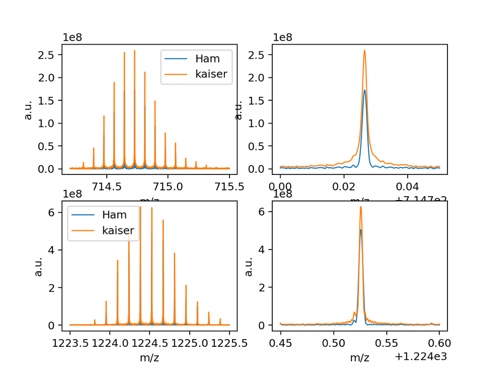

```python
real1()
```

## truncated to 1M points

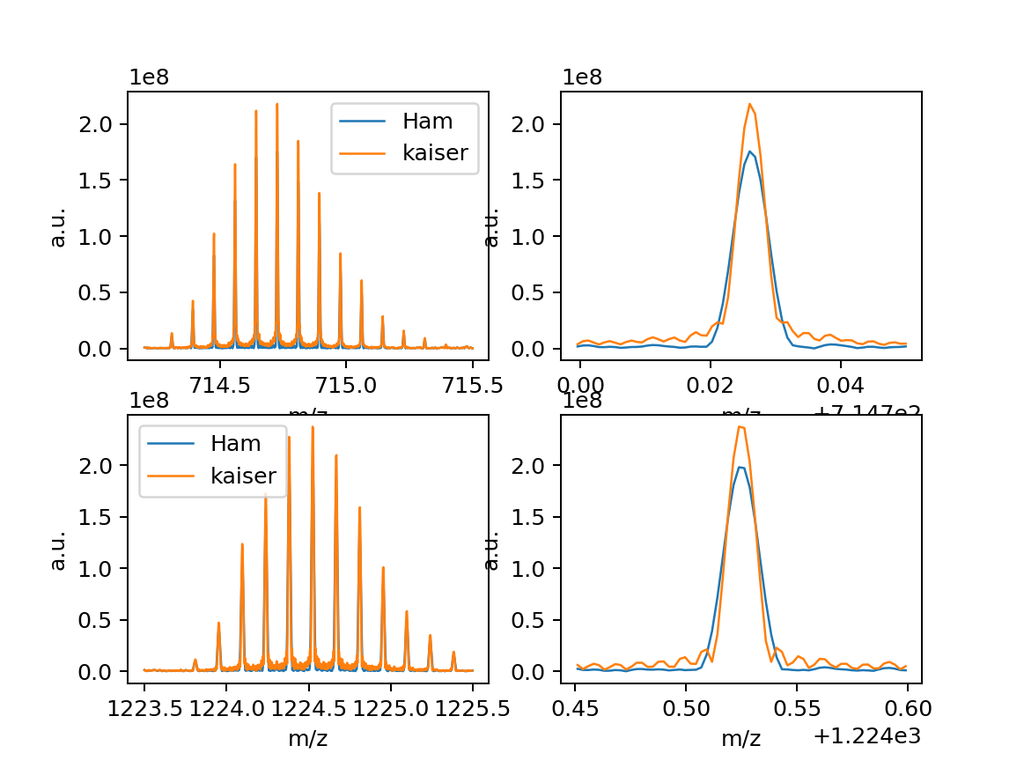

```python
real1(1024*1024)
```

[figure not shown]

```python
d1 = d.copy().zf(4).rfft().modulus().set_unit('m/z').display()
```

```python
def real2():
    d = Apex.Import_1D('files/FTICR-Files/080617-insulin_2M_MS_000001.d')
    #d.chsize(256*1024)
    zm1 = (963,965)
    zm2 = (1444, 1446.5)
    (fig,ax) = plt.subplots(nrows=2, ncols=1)
    d1 = d.copy().zf(4).rfft().modulus().set_unit('m/z').display(zoom=zm1, figure=ax[0])
    d1.display(zoom=zm2, figure=ax[1])
    d2 = d.copy().hamming().zf(4).rfft().modulus().set_unit('m/z').display(zoom=zm1,figure=ax[0])
    d2.display(zoom=zm2, figure=ax[1])
    d3 = d.copy().apod_sin(0.5).zf(4).rfft().modulus().set_unit('m/z').display(zoom=zm1,figure=ax[0])
    d3.display(zoom=zm2, figure=ax[1])
```

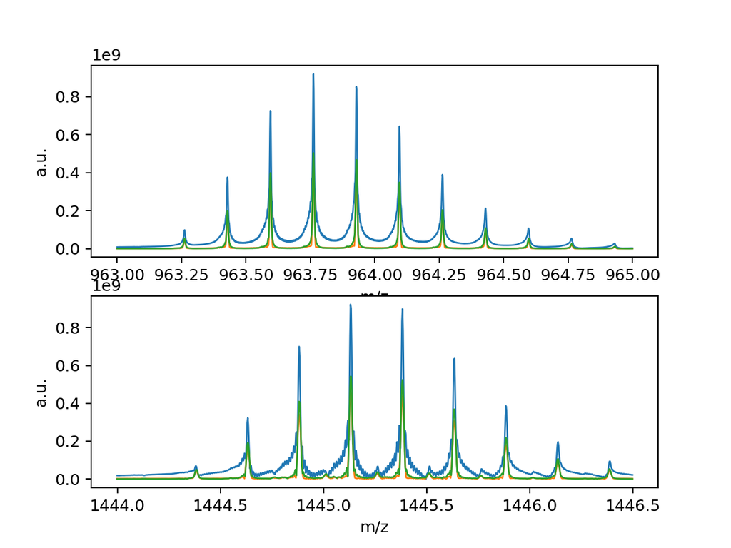

```python
real2()
```

# Phasing

FT is instrinsically complex

[figure not shown]

## Some remarks

- all spectra so far were in modulus ( `.modulus()` )
- phase of a line is equivalent to starting point of the signal
- phase of each line accumulates at their respective frequency as soon as they are excited $\Rightarrow$ **phase dependence linear with frequency**
- because of swept pulse, each line starts at a different moment during the pulse $\Rightarrow$ **phase dependence quadratic with frequency**
- each line in the spectrum has a phase $\phi$, function of the frequency of the line $\phi(f)$ $$ \phi(f) \propto \phi_o + a f + b f^2 $$
- but phase is defined only on $[0..2\pi]$ so there is no continuity $\Rightarrow$ tricky to correct

```python
d = Solarix.Import_1D("/DATA/Phasage FTICR/cyto_C phased/cytoC_ms_000001.d").apod_sq_sin(0.1).zf(4).rfft().set_unit('m/z')
dap = Solarix.Import_1D("/DATA/Phasage FTICR/cyto_C phased/cytoC_ms_000001.d").apod_sq_sin(0.35).zf(4).rfft().set_unit('m/z')
def ph(ex, apod=False):
    if apod:
        dd = dap
    else:
        dd = d
    (fig, ax) = plt.subplots(nrows=2,ncols=1,sharex=True)
    dz = dd.copy().set_unit('m/z').extract(ex[0],ex[1]).display(figure=ax[0])
    dz = dd.copy().set_unit('m/z').extract(ex[0],ex[1]).phase(ex[3],ex[4]).apmin().display(figure=ax[1])
```

## some examples

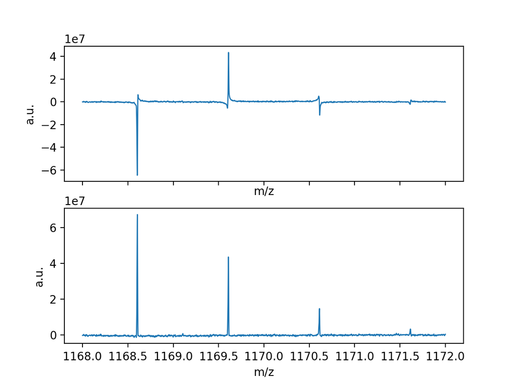

```python
ph((1168,1172,1438.011050,241.250000,905.000000))
```

## In addition

because of the width of the dispersive part is (much) wider than the absorptive part, the phase rotation of the dispersive part can "walk" on the absorptive part of the line nearby, and thus appear in the phased spectrum.

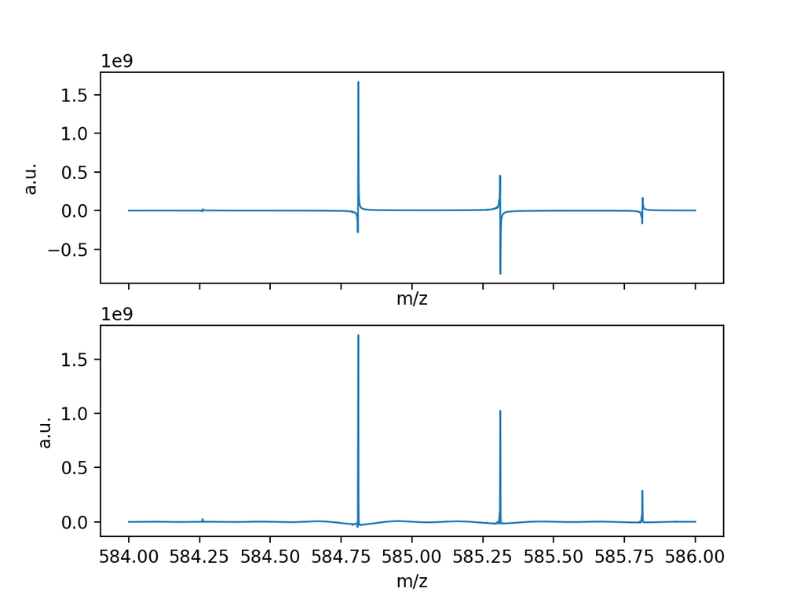

```python
ph((584,586,694.202733,125.000000,3742.076883))
```

The effect is stronger at low masses (high frequency $\Rightarrow$ fast phase rotation)

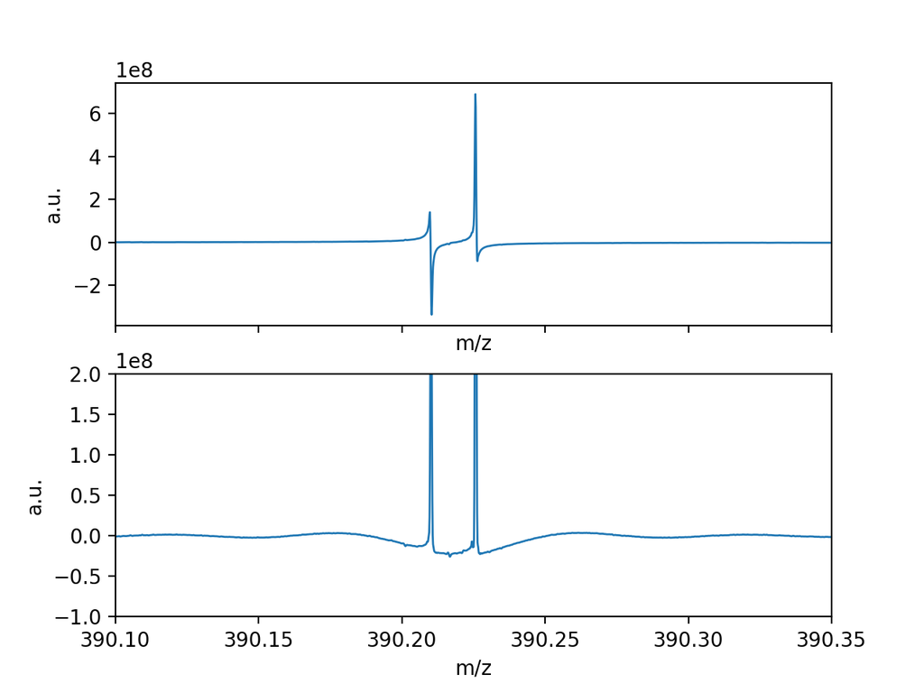

```python
ph((390,392,460.252428,170.000000,12654.099460))
plt.xlim(xmin = 390.10, xmax=390.35); plt.ylim(ymin = -1E8, ymax=2E8);
```

On these examples, a very mild apodisation was used, in order keep the line shape as natural as possible.

The baseline effect can be reduced by applying a somewhat stronger apodisation, with some other artifacts appearing:

- more noise
- sharp negative wings on the sides of the peaks

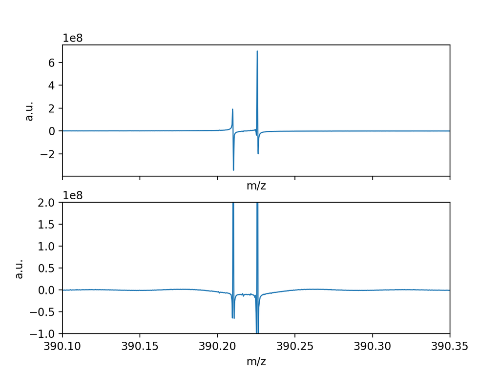

```python
ph((390,392,460.252428,170.000000,12654.099460), apod=True)
plt.xlim(xmin = 390.10, xmax=390.35); plt.ylim(ymin = -1E8, ymax=2E8);
```

# 2D FTICR-MS

see joined notebook

# NUS

see joined notebook

```python
%%bash
# This notebook is organized as a slide show,
# run this cell to display the interactive slides
jupyter nbconvert Advanced.ipynb --to slides
mv Advanced.slides.html files/
cd files; python -m nbconvert.postprocessors.serve Advanced.slides.html
```

```
Process is terminated.
```